# Homework 2

Author

Ridhi Bandaru

# Problem 1

For our first problem, we will use data obtained from past Eurovision song contests. The data can be found as contestants.Rda and votes.Rda on HuskyCT.

## Part A

Part A of the problem will concern the data available in contestants.Rda.

```r
library(dplyr)
library(ggplot2)
library(tidyverse)
library(janitor)
```

### Question (i). 8 points.

Load the “contestants” data frame into R.

```r
load("contestants.Rda")
contestants |>
  glimpse()
```

```
Rows: 1,734
Columns: 21
$ year              <dbl> 1956, 1956, 1956, 1956, 1956, 1956, 1956, 1956, 1956…
$ to_country_id     <chr> "ch", "nl", "be", "de", "fr", "lu", "it", "nl", "be"…
$ to_country        <chr> "Switzerland", "Netherlands", "Belgium", "Germany", …
$ performer         <chr> "Lys Assia", "Jetty Paerl", "Fud Leclerc", "Walter A…
$ song              <chr> "Refrain", "De Vogels Van Holland", "Messieurs Les N…
$ place_contest     <dbl> 2, 2, 2, 2, 2, 2, 2, 2, 2, 2, 2, 2, 1, 2, 3, 4, 4, 6…
$ sf_num            <dbl> NA, NA, NA, NA, NA, NA, NA, NA, NA, NA, NA, NA, NA, …
$ running_final     <dbl> 2, 1, 3, 4, 5, 13, 7, 8, 10, 11, 12, 14, 6, 8, 9, 2,…
$ running_sf        <dbl> NA, NA, NA, NA, NA, NA, NA, NA, NA, NA, NA, NA, NA, …
$ place_final       <dbl> 2, 2, 2, 2, 2, 2, 2, 2, 2, 2, 2, 2, 1, 2, 3, 4, 4, 6…
$ points_final      <dbl> NA, NA, NA, NA, NA, NA, NA, NA, NA, NA, NA, NA, 31, …
$ place_sf          <dbl> NA, NA, NA, NA, NA, NA, NA, NA, NA, NA, NA, NA, NA, …
$ points_sf         <dbl> NA, NA, NA, NA, NA, NA, NA, NA, NA, NA, NA, NA, NA, …
$ points_tele_final <dbl> NA, NA, NA, NA, NA, NA, NA, NA, NA, NA, NA, NA, NA, …
$ points_jury_final <dbl> NA, NA, NA, NA, NA, NA, NA, NA, NA, NA, NA, NA, NA, …
$ points_tele_sf    <dbl> NA, NA, NA, NA, NA, NA, NA, NA, NA, NA, NA, NA, NA, …
$ points_jury_sf    <dbl> NA, NA, NA, NA, NA, NA, NA, NA, NA, NA, NA, NA, NA, …
$ composers         <chr> "Georg Benz Stahl", "Cor Lemaire", "Jacques Say;Jean…
$ lyricists         <chr> NA, "Annie M. G. Schmidt", "Robert Montal", NA, "Rac…
$ lyrics            <chr> "(Refrain d'amour...)\\n\\nRefrain, couleur du ciel,…
$ youtube_url       <chr> "https://youtube.com/watch?v=IyqIPvOkiRk", "https://…
```

Using this data frame as a starting point, apply dplyr verbs to create another data frame which meets the following criteria:

- include exactly two columns: one named performer, and another named nperformances. The cells of performer should give the names of performers. The cells in nperformances should tell us the number of times a performer appeared in the dataset.
- Do not include any performers with fewer than three Eurovision performances.
- Sort the rows such that they are in descending order based on the number of performances. For example, anyone with four performances should appear above anyone with three performances.

```r
performances <- contestants |>
  select(performer) |>
  group_by(performer) |>
  count() |>
  rename(nperformances = n) |>
  filter(nperformances >= 3) |>
  arrange(desc(nperformances))
```

```r
performances
```

```
# A tibble: 14 × 2
# Groups:   performer [14]
   performer           nperformances
   <chr>                       <int>
 1 Fud Leclerc                     4
 2 Chiara                          3
 3 Corry Brokken                   3
 4 Domenico Modugno                3
 5 Evridiki                        3
 6 Katja Ebstein                   3
 7 Kirsti Sparboe                  3
 8 Loreen                          3
 9 Lys Assia                       3
10 Peter, Sue and Marc             3
11 Romuald                         3
12 Udo Jürgens                     3
13 Valentina Monetta               3
14 Wind                            3
```

### Question (ii). 8 points.

Using dplyr verbs, create a one-row data frame that reports the number of missing values in each column of the original contestants data frame.

```r
missing_counts <- contestants |>
  summarise(across(everything(), ~sum(is.na(.))))
```

```r
missing_counts
```

```
# A tibble: 1 × 21
   year to_country_id to_country performer  song place_contest sf_num
  <int>         <int>      <int>     <int> <int>         <int>  <int>
1     0             0          0         0     3            56   1094
# ℹ 14 more variables: running_final <int>, running_sf <int>,
#   place_final <int>, points_final <int>, place_sf <int>, points_sf <int>,
#   points_tele_final <int>, points_jury_final <int>, points_tele_sf <int>,
#   points_jury_sf <int>, composers <int>, lyricists <int>, lyrics <int>,
#   youtube_url <int>
```

### Question (iii). 8 points.

Occasionally, a country in contestants has had more than one performer in a given year. How many times does this occur in the contestants data frame?

```r
multiple_performers_count <- contestants |>
  distinct(year, to_country, performer) |>
  group_by(to_country, year) |>
  count() |>
  filter(n>1) |>
  rename(nperformers = n,
         country = to_country)
```

```r
multiple_performers_count
```

```
# A tibble: 5 × 3
# Groups:   country, year [5]
  country      year nperformers
  <chr>       <dbl>       <int>
1 Belgium      1956           2
2 France       1956           2
3 Germany      1956           2
4 Italy        1956           2
5 Netherlands  1956           2
```

This happens 5 different times. The table above enumerates the countries that had multiple performers in a given year and which years. All these times, there were 2 different performers.

### Question (iv). 8 points.

To eliminate the cases discovered in (iii), create a new data frame named contestants_fixed.

contestants_fixed should be identical to contestants, except it should contain at most one performer for each country-year combination. If more there is more than one performer for a country-year combination in contestants, contestants_fixed should keep only the one with the highest running_final score.

Hint: if using a slice_max verb, it may be helpful to include a with_ties = FALSE argument.

```r
contestants_fixed <- contestants |>
  group_by(to_country, year) |>
  slice_max(order_by = running_final, n = 1, with_ties = FALSE) |>
  ungroup()
```

```r
contestants_fixed
```

```
# A tibble: 1,714 × 21
    year to_country_id to_country performer           song  place_contest sf_num
   <dbl> <chr>         <chr>      <chr>               <chr>         <dbl>  <dbl>
 1  2004 al            Albania    Anjeza Shahini      The …             7      0
 2  2005 al            Albania    Ledina Celo         Tomo…            16     NA
 3  2006 Albania       Albania    Luiz Ejlli          Zjar…            28      0
 4  2007 Albania       Albania    Aida & Frederik Nd… Hear…            31      0
 5  2008 al            Albania    Olta Boka           Zemr…            17      2
 6  2009 al            Albania    Kejsi Tola          Carr…            17      2
 7  2010 al            Albania    Juliana Pasha       It's…            16      1
 8  2011 Albania       Albania    Aurela Gaçe         Feel…            30      1
 9  2012 al            Albania    Rona Nishliu        Suus              5      1
10  2013 Albania       Albania    Adrian Lulgjuraj &… Iden…            34      2
# ℹ 1,704 more rows
# ℹ 14 more variables: running_final <dbl>, running_sf <dbl>,
#   place_final <dbl>, points_final <dbl>, place_sf <dbl>, points_sf <dbl>,
#   points_tele_final <dbl>, points_jury_final <dbl>, points_tele_sf <dbl>,
#   points_jury_sf <dbl>, composers <chr>, lyricists <chr>, lyrics <chr>,
#   youtube_url <chr>
```

### Question (v). 8 points.

Using the data frame you created in (iv), create a new data frame “contestants_fixed_wider” where:

- each row represents a year,
- each column is a country, and
- the cell values are the number of points each country got in the final (i.e. the variable named points_final). If a country didn’t participate in the final, the cell value should be NA.

```r
contestants_fixed_wider <- contestants_fixed |>
  select(to_country, year, points_final) |>
  pivot_wider(
    names_from = to_country,
    values_from = points_final
  )
```

```r
contestants_fixed_wider
```

```
# A tibble: 68 × 55
    year Albania Andorra Armenia Australia Austria Azerbaijan Belarus Belgium
   <dbl>   <dbl>   <dbl>   <dbl>     <dbl>   <dbl>      <dbl>   <dbl>   <dbl>
 1  2004     106      NA      NA        NA       9         NA      NA       7
 2  2005      53      NA      NA        NA      NA         NA      NA      NA
 3  2006      NA      NA     129        NA      NA         NA      NA      NA
 4  2007      NA      NA     138        NA      NA         NA     145      NA
 5  2008      55      NA     199        NA      NA        132      NA      NA
 6  2009      48      NA      92        NA      NA        207      NA      NA
 7  2010      62      NA     141        NA      NA        145      18     143
 8  2011      NA      NA      NA        NA      64        221      NA      NA
 9  2012     146      NA      NA        NA      NA        150      NA      NA
10  2013      NA      NA      41        NA      NA        234      48      71
# ℹ 58 more rows
# ℹ 46 more variables: `Bosnia & Herzegovina` <dbl>, Bulgaria <dbl>,
#   Croatia <dbl>, Cyprus <dbl>, `Czech Republic` <dbl>, Czechia <dbl>,
#   Denmark <dbl>, Estonia <dbl>, Finland <dbl>, France <dbl>, Georgia <dbl>,
#   Germany <dbl>, Greece <dbl>, Hungary <dbl>, Iceland <dbl>, Ireland <dbl>,
#   Israel <dbl>, Italy <dbl>, Latvia <dbl>, Lithuania <dbl>, Luxembourg <dbl>,
#   Malta <dbl>, Moldova <dbl>, Monaco <dbl>, Montenegro <dbl>, …
```

## Part B

Part B will concern the data available in votes.Rda

### Question (i). 6 points.

Start by loading the votes data into R.

```r
load("votes.Rda")
votes |>
  glimpse()
```

```
Rows: 51,354
Columns: 7
$ year         <dbl> 1957, 1957, 1957, 1957, 1957, 1957, 1957, 1957, 1957, 195…
$ round        <chr> "final", "final", "final", "final", "final", "final", "fi…
$ to_country   <chr> "Netherlands", "France", "Denmark", "Luxembourg", "German…
$ from_country <chr> "Austria", "Austria", "Austria", "Austria", "Austria", "A…
$ total_points <dbl> 6, 0, 0, 3, 0, 0, 1, 0, 0, 0, 5, 2, 0, 0, 1, 1, 1, 0, 0, …
$ tele_points  <dbl> NA, NA, NA, NA, NA, NA, NA, NA, NA, NA, NA, NA, NA, NA, N…
$ jury_points  <dbl> NA, NA, NA, NA, NA, NA, NA, NA, NA, NA, NA, NA, NA, NA, N…
```

Then, create a new data frame called votes_complete. votes_complete should contain only those rows which have non-NA observations for both the tele_points and jury_points variables.

```r
votes_complete <- votes |>
  filter(!is.na(tele_points) & !is.na(jury_points))
```

How many years are represented in this new votes_complete data frame?

```r
unique_years <- votes_complete |>
  distinct(year) |>
  nrow()
unique_years
```

```
[1] 7
```

There are 7 years represented in the new votes_complete data frame.

### Question (ii). 8 points.

Apply dplyr verbs to transform votes_complete into a new data frame named votes_complete_agg with 5 columns: year, from_country, to_country, tele_points, and jury_points.

tele_points and jury_points should be the sum of these values across the three rounds: final, semi-final-1, and semi-final-2.

```r
votes_complete_agg <- votes_complete |>
  group_by(year, from_country, to_country) |>
  summarise(
    tele_points = sum(tele_points, na.rm = TRUE),
    jury_points = sum(jury_points, na.rm = TRUE)
  )
votes_complete_agg
```

```
# A tibble: 9,245 × 5
# Groups:   year, from_country [284]
    year from_country to_country tele_points jury_points
   <dbl> <chr>        <chr>            <dbl>       <dbl>
 1  2016 Albania      Albania              0           0
 2  2016 Albania      Armenia              2           0
 3  2016 Albania      Australia           18          22
 4  2016 Albania      Austria              0           0
 5  2016 Albania      Azerbaijan           0           0
 6  2016 Albania      Belarus              0           0
 7  2016 Albania      Belgium              8           0
 8  2016 Albania      Bulgaria            15          11
 9  2016 Albania      Croatia              0           0
10  2016 Albania      Cyprus               0           0
# ℹ 9,235 more rows
```

Over the years, which four countries sent the most jury points to Poland?

```r
to_poland <- votes_complete_agg |>
  filter(to_country == 'Poland') |>
  group_by(from_country) |>
  summarise(jury_points = sum(jury_points, na.rm = TRUE)) |>
  arrange(desc(jury_points)) |>
  select(from_country,
         jury_points)
head(to_poland)
```

```
# A tibble: 6 × 2
  from_country   jury_points
  <chr>                <dbl>
1 San Marino              27
2 Australia               22
3 Azerbaijan              21
4 Israel                  21
5 United Kingdom          20
6 Czech Republic          19
```

Over the years, San Marino (27), Australia (22), Azerbaijan (21) and Isreal (21) sent the most jury points to Poland.

### Question (iii). 10 points.

Consider the countries Sweden, Denmark, and Norway.

Transform votes_complete_agg into a data frame that can be used to create the following faceted plot.

```r
scandinavia <- votes_complete_agg |>
  select(to_country, from_country, year, jury_points, tele_points) |>
  filter(to_country == "Sweden" | to_country == "Denmark" | to_country == "Norway") |>
  filter(from_country == "Sweden" | from_country == "Denmark" | from_country == "Norway")
scandinavia
```

```
# A tibble: 55 × 5
# Groups:   year, from_country [21]
   to_country from_country  year jury_points tele_points
   <chr>      <chr>        <dbl>       <dbl>       <dbl>
 1 Denmark    Denmark       2016           0           0
 2 Norway     Denmark       2016           6          10
 3 Sweden     Denmark       2016           4          12
 4 Denmark    Norway        2016           0           5
 5 Norway     Norway        2016           0           0
 6 Sweden     Norway        2016           0           7
 7 Sweden     Sweden        2016           0           0
 8 Denmark    Denmark       2017           0           0
 9 Norway     Denmark       2017          18          17
10 Sweden     Denmark       2017          12          12
# ℹ 45 more rows
```

Note that the plot shows how the jury_points and tele_points exchanged between these countries varied from year to year. Once you have the correct data frame, recreate the plot.

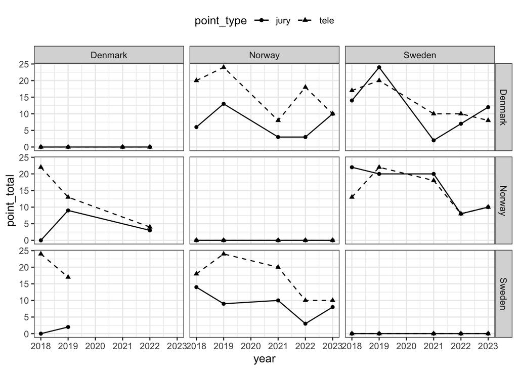

```r
theme_set(theme_bw())
scandinavia |>
  ggplot(aes(x = year)) +
  xlim(2018,2023) +
  geom_line(aes(y = jury_points, linetype = "jury")) +
  geom_line(aes(y = tele_points, linetype = "tele")) +
  geom_point(aes(y = jury_points, shape = "jury")) +
  geom_point(aes(y = tele_points, shape = "tele")) +
  facet_grid(from_country ~ to_country) +
  labs(x = "year",
       y = "point_total") +
  scale_linetype_manual(values = c("tele" = 44, "jury" = 1),
                        name = "point_type") +
  scale_shape_manual(values = c("jury" = 16, "tele" = 17),
                     name = "point_type") +
  theme(legend.position = "top")
```

# Problem 2

## Part A. 30 points.

Attached to the homework on HuskyCT, there are four Rda files: tmax.Rda, tmin.Rda, prcp.Rda, and tmax_tmin_prcp.Rda. These files provide historical weather data for four cities: Philadelphia, PA; Pittsburgh, PA; Erie, PA; Cleveland, OH. tmax is the max daily temperature, tmin is the min daily temperature, and prcp is the daily precipitation.

tmax.Rda, tmin.Rda, prcp.Rda are untidy representations of pieces of the weather data—one for tmax, one for tmin, and one for prcp. tmax_tmin_prcp.Rda is a tidy version of the three datasets brought together.

Your task is to use tmax.Rda, tmin.Rda, and prcp.Rda to exactly replicate the contents of tmax_tmin_prcp.Rda. This should be accomplished through a series of tidyverse verbs.

Please provide all the code to go from tmax.Rda, tmin.Rda, and prcp.Rda to a single dataframe matching tmax_tmin_prcp.

```r
load("tmax.Rda")
load("tmin.Rda")
load("prcp.Rda")
load("tmax_tmin_prcp.Rda")
```

```r
tmax_tidy <- tmax |>
  pivot_longer(cols = -year,
               names_to = "column_name",
               values_to = "tmax") |>
  separate(column_name, into = c("City", "State", "Day", "Month"), sep = ",") |>
  mutate(City = fct_recode(City,
                                "Pittsburgh" = "pit",
                                "Philadelphia" = "phi",
                                "Erie" = "eri",
                                "Cleveland" = "cle")) |>
  mutate(State = fct_recode(State,
                                "PA" = "pa",
                                "OH" = "oh"))

tmax_tidy |>
  glimpse()
```

```
Rows: 221,064
Columns: 6
$ year  <dbl> 1871, 1871, 1871, 1871, 1871, 1871, 1871, 1871, 1871, 1871, 1871…
$ City  <fct> Pittsburgh, Pittsburgh, Pittsburgh, Pittsburgh, Pittsburgh, Pitt…
$ State <fct> PA, PA, PA, PA, PA, PA, PA, PA, PA, PA, PA, PA, PA, PA, PA, PA, …
$ Day   <chr> "01", "02", "03", "04", "05", "06", "07", "08", "09", "10", "11"…
$ Month <chr> "01", "01", "01", "01", "01", "01", "01", "01", "01", "01", "01"…
$ tmax  <dbl> NA, NA, NA, NA, NA, NA, NA, NA, NA, NA, NA, NA, NA, NA, NA, NA, …
```

```r
tmin_tidy <- tmin |>
  pivot_longer(cols = -c(year, month),
               names_to = "column_name",
               values_to = "tmin") |>
  separate(column_name, into = c("City", "State", "Day"), sep = "_") |>
  mutate(City = fct_recode(City,
                                "Pittsburgh" = "pit",
                                "Philadelphia" = "phi",
                                "Erie" = "eri",
                                "Cleveland" = "cle")) |>
  mutate(State = fct_recode(State,
                                "PA" = "pa",
                                "OH" = "oh")) |>
  rename("Month" = month)

tmin_tidy |>
  glimpse()
```

```
Rows: 224,688
Columns: 6
$ year  <dbl> 1871, 1871, 1871, 1871, 1871, 1871, 1871, 1871, 1871, 1871, 1871…
$ Month <chr> "01", "01", "01", "01", "01", "01", "01", "01", "01", "01", "01"…
$ City  <fct> Pittsburgh, Pittsburgh, Pittsburgh, Pittsburgh, Pittsburgh, Pitt…
$ State <fct> PA, PA, PA, PA, PA, PA, PA, PA, PA, PA, PA, PA, PA, PA, PA, PA, …
$ Day   <chr> "01", "02", "03", "04", "05", "06", "07", "08", "09", "10", "11"…
$ tmin  <dbl> NA, NA, NA, NA, NA, NA, NA, NA, NA, NA, NA, NA, NA, NA, NA, NA, …
```

```r
prcp_tidy <- prcp |>
  pivot_longer(cols = -c(year, city, state),
               names_to = c("day", "month"),
               names_pattern = "date(.*)__(.*)",
               values_to = "prcp") |>
  rename("City" = city,
         "Month" = month,
         "Day" = day,
         "State" = state)

prcp_tidy |>
  glimpse()
```

```
Rows: 216,306
Columns: 6
$ year  <dbl> 1871, 1871, 1871, 1871, 1871, 1871, 1871, 1871, 1871, 1871, 1871…
$ City  <chr> "Pittsburgh", "Pittsburgh", "Pittsburgh", "Pittsburgh", "Pittsbu…
$ State <chr> "PA", "PA", "PA", "PA", "PA", "PA", "PA", "PA", "PA", "PA", "PA"…
$ Day   <chr> "01", "02", "03", "04", "05", "06", "07", "08", "09", "10", "11"…
$ Month <chr> "01", "01", "01", "01", "01", "01", "01", "01", "01", "01", "01"…
$ prcp  <dbl> 0.00, 0.00, 0.00, 0.00, 0.00, 0.00, 0.00, 0.04, 0.13, 0.00, 0.00…
```

```r
tmax_tmin_prcp_tidy <- tmax_tidy |>
  left_join(tmin_tidy) |>
  left_join(prcp_tidy) |>
  mutate(Day = as.integer(Day)) |>
  select(Day, Month, year, City, State, tmax, tmin, prcp)
tmax_tmin_prcp_tidy |>
  glimpse()
```

```
Rows: 221,064
Columns: 8
$ Day   <int> 1, 2, 3, 4, 5, 6, 7, 8, 9, 10, 11, 12, 13, 14, 15, 16, 17, 18, 1…
$ Month <chr> "01", "01", "01", "01", "01", "01", "01", "01", "01", "01", "01"…
$ year  <dbl> 1871, 1871, 1871, 1871, 1871, 1871, 1871, 1871, 1871, 1871, 1871…
$ City  <chr> "Pittsburgh", "Pittsburgh", "Pittsburgh", "Pittsburgh", "Pittsbu…
$ State <chr> "PA", "PA", "PA", "PA", "PA", "PA", "PA", "PA", "PA", "PA", "PA"…
$ tmax  <dbl> NA, NA, NA, NA, NA, NA, NA, NA, NA, NA, NA, NA, NA, NA, NA, NA, …
$ tmin  <dbl> NA, NA, NA, NA, NA, NA, NA, NA, NA, NA, NA, NA, NA, NA, NA, NA, …
$ prcp  <dbl> 0.00, 0.00, 0.00, 0.00, 0.00, 0.00, 0.00, 0.04, 0.13, 0.00, 0.00…
```

```r
if(all(names(tmax_tmin_prcp) == names(tmax_tmin_prcp_tidy))) {
  print("Column names match.")
} else {
  print("Column names do not match.")
}
```

```
[1] "Column names match."
```

```r
# Check if all rows are included
anti_join(tmax_tmin_prcp, tmax_tmin_prcp_tidy) |>
  summarise(rows_not_in_df2 = n())
```

```
# A tibble: 1 × 1
  rows_not_in_df2
            <int>
1               0
```

## Part B

### Question (i). 6 points.

Consider the data in tmax_tmin_prcp.Rda from 1971 to 2017. Is there any pattern to which days are missing temperatures? What do you think is causing this?

```r
missing1 <- tmax_tmin_prcp |>
  filter(is.na(tmax) | is.na(tmin)) |>
  filter(year >= 1971 & year < 2018)
missing1
```

```
# A tibble: 142 × 8
     Day Month  year City         State  tmax  tmin  prcp
   <dbl> <chr> <dbl> <chr>        <chr> <dbl> <dbl> <dbl>
 1    29 02     1971 Pittsburgh   PA       NA    NA    NA
 2    29 02     1971 Philadelphia PA       NA    NA    NA
 3    29 02     1971 Erie         PA       NA    NA    NA
 4    29 02     1971 Cleveland    OH       NA    NA    NA
 5    29 02     1973 Pittsburgh   PA       NA    NA    NA
 6    29 02     1973 Philadelphia PA       NA    NA    NA
 7    29 02     1973 Erie         PA       NA    NA    NA
 8    29 02     1973 Cleveland    OH       NA    NA    NA
 9    29 02     1974 Pittsburgh   PA       NA    NA    NA
10    29 02     1974 Philadelphia PA       NA    NA    NA
# ℹ 132 more rows
```

```r
missing2 <- missing1 |>
  filter(year > 1971)
missing2
```

```
# A tibble: 138 × 8
     Day Month  year City         State  tmax  tmin  prcp
   <dbl> <chr> <dbl> <chr>        <chr> <dbl> <dbl> <dbl>
 1    29 02     1973 Pittsburgh   PA       NA    NA    NA
 2    29 02     1973 Philadelphia PA       NA    NA    NA
 3    29 02     1973 Erie         PA       NA    NA    NA
 4    29 02     1973 Cleveland    OH       NA    NA    NA
 5    29 02     1974 Pittsburgh   PA       NA    NA    NA
 6    29 02     1974 Philadelphia PA       NA    NA    NA
 7    29 02     1974 Erie         PA       NA    NA    NA
 8    29 02     1974 Cleveland    OH       NA    NA    NA
 9    29 02     1975 Pittsburgh   PA       NA    NA    NA
10    29 02     1975 Philadelphia PA       NA    NA    NA
# ℹ 128 more rows
```

```r
missing3 <- missing1 |>
  filter(year == 1980 | year == 1984)
missing3
```

```
# A tibble: 0 × 8
# ℹ 8 variables: Day <dbl>, Month <chr>, year <dbl>, City <chr>, State <chr>,
#   tmax <dbl>, tmin <dbl>, prcp <dbl>
```

```r
missing4 <- missing1 |>
  filter(year %% 4 == 0)
missing4
```

```
# A tibble: 0 × 8
# ℹ 8 variables: Day <dbl>, Month <chr>, year <dbl>, City <chr>, State <chr>,
#   tmax <dbl>, tmin <dbl>, prcp <dbl>
```

### BONUS Question (ii). 10 Points.

Provide code to create the following graphic showing the average maximum and minimum temperature per year across the four cities from 1971 to 2017.

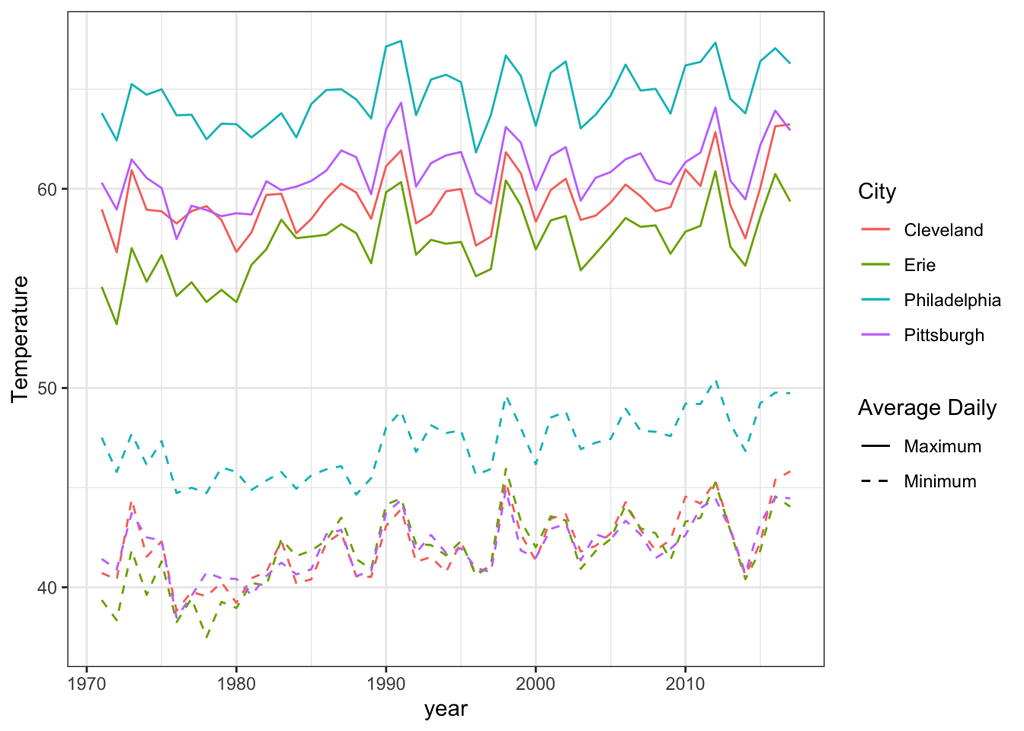

```r
tmax_tmin_prcp |>
  filter(year >= 1971 & year < 2018) |>
  group_by(year, City) %>%
  summarize(avg_tmin = mean(tmin, na.rm = TRUE),
            avg_tmax = mean(tmax, na.rm = TRUE)) |>
  ggplot(aes(x = year,
             color = City,
             linetype = c(avg_tmin),(avg_tmax))) +
  geom_line(aes(y=avg_tmin, linetype="Minimum")) +
  geom_line(aes(y=avg_tmax, linetype="Maximum")) +
  labs(x = "year",
       y = "Temperature") +
  scale_linetype_manual(values = c("Minimum" = 44, "Maximum" = 1),
                        name = "Average Daily")
```